# Hypertension_Simulation

Hemanshu Das

5/21/2019

The intervention considered is simplistic wherein everyone in the treatment cohort has access to hypertension treatment.

```r
#Model Inputs
n.i <- 1000                            #Number of individuals
ini_age <- 50                           #Start Age of Cohort
end_age <- 80                           #Simulation End Age
cl <- 1                                 #Number of Cycle in a year
v.n <- c("W","MI","ST","postMI","postST","cD","D")        #Model States: W-Well, CVD-CVD Event, MI - Myocardial Infraction Transitory State, ST- Transitory Stroke State, cD - CVD Death, D - Death due to other causes
n.s <- length(v.n)                      #Number of model states
v.M_1 <- rep("W",n.i)                   #Everyone is Well at the start
v.Str <- c("No Treatment","Treatment")  #Storing the Strategy Indicator
n.t <- (end_age - ini_age)*12                #Simulation cycles
d.c   <- d.e <- 0.03/12                    #Equal discounting of costs and QALYs by 3% p.a

#Initialization of Transition Probabilities (Monthly transition)
p.W_CVD <- 0.00206                  #Probability of CVD transitory event when well; 50 yr, M, Smoker, SBP 150mmHg, BMI 27.7
p.CVD_MI <- 0.188                  #Probability of MI when CVD event occurs
p.CVD_ST <- 1 - p.CVD_MI           #Probability of Stroke when CVD event occurs
p.MI_cD <- 0.335                   #Probability of fatal outcome when MI occurs
p.ST_cD <- 0.181                   #Probability of fatal outcome when Stroke occurs
p.MI_postMI <- 1 - p.MI_cD         #Probability of non-fatal outcome when MI occurs
p.ST_postST <- 1 - p.ST_cD         #Probability of non-fatal outcome when Stroke occurs
p.postMI_cD <- 0.0022*0.76              #Probability of CVD death post non-fatal MI
p.postMI_D <- 0.0022*0.24              #Probability of death post non-fatal MI
p.postST_cD <- 0.0028 *0.336             #Probability of CVD death post non-fatal ST
p.postST_D <- 0.0028 *0.664             #Probability of death post non-fatal ST
p.W_D <- 0.00054                   #Probability of normal death from any state

#Intiatlization of Cost for each state
c.W <- 0                      #cost of being well
c.MI <- 1428.57                  #cost of acute MI treatment (Assumed to be INR 1,00,000)
c.ST <- 2142.85                  #cost of acute Stroke treatment (Assumed to be INR 1,50,000)
c.postMI <- c.postST <- 28.57 #cost of follow up care (Assumed to be INR 2000 p.m)
c.D <- c.cD <- 0              #cost of Death

#Intialization of Utility for each state
u.W <- 1                      #utility of being well
u.MI <- u.postMI <- 0.76                  #utility of MI state
u.ST <- u.postST <- 0.629                 #utility of Stroke state
u.D <- u.cD <- 0              #utility of death

# If not treated
p.W_CVD_NT <- 0.00206          #15% reduction in CVD risk
c.W_NT <- 0                   #Cost of medication and consultation in a month

# If treated
p.W_CVD_T <- 0.00172          #15% reduction in CVD risk
c.W_T <- 4.57                 #Cost of medication and consultation in a month
```

# Running the simulations

```
##              CVD Events Non-CVD Deaths CVD Deaths Costs($)    QALYs   ICER
## No Treatment        450            232        141     1482 191.3259
## Treatment           393            227        119     2113 196.0012 135.05
```

According to WHO, if the ICER is less than thrice the GDP per Capita, the investment in the intervention should be pursued. There are alternative aproaches as well, but I haven’t explored them yet.

# Diesease transition when No Treatment is provided

```
##           Cycle 1 Cycle 2 Cycle 3 Cycle 4 Cycle 5 Cycle 6 Cycle 7 Cycle 8
## Well         1000     993     990     990     985     984     982     982
## CVD Death       0       0       1       2       2       2       2       2
## Death           0       2       4       4       6       6       6       6
##           Cycle 9 Cycle 10 Cycle 11 Cycle 12 Cycle 13 Cycle 14 Cycle 15
## Well          982      978      978      977      973      972      969
## CVD Death       2        2        2        2        2        2        2
## Death           6       10       10       10       11       11       11
##           Cycle 16 Cycle 17 Cycle 18 Cycle 19 Cycle 20 Cycle 21 Cycle 22
## Well           969      966      966      965      965      963      961
## CVD Death        2        2        3        3        3        3        3
## Death           11       11       11       11       11       11       11
##           Cycle 23 Cycle 24 Cycle 25 Cycle 26 Cycle 27 Cycle 28 Cycle 29
## Well           954      952      952      952      952      951      951
## CVD Death        3        3        3        3        3        3        3
## Death           11       13       13       13       13       14       14
##           Cycle 30 Cycle 31 Cycle 32 Cycle 33 Cycle 34 Cycle 35 Cycle 36
## Well           951      945      942      941      938      938      937
## CVD Death        3        3        3        4        4        4        4
## Death           14       14       15       15       15       15       15
##           Cycle 37 Cycle 38 Cycle 39 Cycle 40 Cycle 41 Cycle 42 Cycle 43
## Well           936      935      924      920      918      917      916
## CVD Death        4        5        5        6        9        9        9
## Death           15       17       17       17       19       20       22
##           Cycle 44 Cycle 45 Cycle 46 Cycle 47 Cycle 48 Cycle 49 Cycle 50
## Well           912      906      897      894      893      891      890
## CVD Death        9        9       10       10       13       15       18
## Death           22       22       26       26       26       26       30
##           Cycle 51 Cycle 52 Cycle 53 Cycle 54 Cycle 55 Cycle 56 Cycle 57
## Well           890      890      885      884      880      880      880
## CVD Death       18       18       18       21       21       21       21
## Death           30       30       30       30       30       30       30
##           Cycle 58 Cycle 59 Cycle 60 Cycle 61 Cycle 62 Cycle 63 Cycle 64
## Well           879      878      875      874      868      866      861
## CVD Death       21       21       21       23       23       23       23
## Death           30       30       36       36       40       42       43
##           Cycle 65 Cycle 66 Cycle 67 Cycle 68 Cycle 69 Cycle 70 Cycle 71
## Well           861      860      860      855      855      853      851
## CVD Death       23       23       23       23       23       23       23
## Death           43       43       43       43       43       45       45
```

[output cut: 177 more lines]

```
## Well            449       447       447       447       446       442
## CVD Death       129       129       129       129       129       129
## Death           217       219       220       222       223       225
##           Cycle 346 Cycle 347 Cycle 348 Cycle 349 Cycle 350 Cycle 351
## Well            442       441       441       441       439       438
## CVD Death       130       130       131       131       131       131
## Death           225       225       225       226       226       226
##           Cycle 352 Cycle 353 Cycle 354 Cycle 355 Cycle 356 Cycle 357
## Well            435       435       431       429       428       426
## CVD Death       132       135       135       137       137       138
## Death           226       226       229       232       232       232
##           Cycle 358 Cycle 359 Cycle 360 Cycle 361
## Well            424       423       422       422
## CVD Death       140       140       141       141
## Death           232       232       232       232
```

# Diesease transition when Treatment is provided

```
##           Cycle 1 Cycle 2 Cycle 3 Cycle 4 Cycle 5 Cycle 6 Cycle 7 Cycle 8
## Well         1000     996     993     993     988     987     984     984
## CVD Death       0       0       1       2       2       2       2       2
## Death           0       0       2       2       4       4       5       5
##           Cycle 9 Cycle 10 Cycle 11 Cycle 12 Cycle 13 Cycle 14 Cycle 15
## Well          984      980      980      979      976      976      974
## CVD Death       2        2        2        2        2        2        2
## Death           5        9        9        9        9        9        9
##           Cycle 16 Cycle 17 Cycle 18 Cycle 19 Cycle 20 Cycle 21 Cycle 22
## Well           974      971      971      970      970      968      967
## CVD Death        2        2        2        2        2        2        2
## Death            9       10       10       10       10       10       10
##           Cycle 23 Cycle 24 Cycle 25 Cycle 26 Cycle 27 Cycle 28 Cycle 29
## Well           962      960      960      960      960      959      959
## CVD Death        2        2        2        2        2        2        2
## Death           10       12       12       12       12       12       12
##           Cycle 30 Cycle 31 Cycle 32 Cycle 33 Cycle 34 Cycle 35 Cycle 36
## Well           959      954      951      950      948      948      947
## CVD Death        2        2        2        3        3        3        3
## Death           12       12       13       13       13       13       13
##           Cycle 37 Cycle 38 Cycle 39 Cycle 40 Cycle 41 Cycle 42 Cycle 43
## Well           946      945      936      932      930      929      927
## CVD Death        3        4        4        5        8        8        8
## Death           13       15       15       15       15       16       17
##           Cycle 44 Cycle 45 Cycle 46 Cycle 47 Cycle 48 Cycle 49 Cycle 50
## Well           923      917      910      907      906      904      900
## CVD Death        8        8        9        9       12       14       14
## Death           17       17       22       22       22       22       26
##           Cycle 51 Cycle 52 Cycle 53 Cycle 54 Cycle 55 Cycle 56 Cycle 57
## Well           900      900      897      896      893      893      893
## CVD Death       17       17       17       20       20       20       20
## Death           26       26       26       26       26       26       26
##           Cycle 58 Cycle 59 Cycle 60 Cycle 61 Cycle 62 Cycle 63 Cycle 64
## Well           893      892      889      887      881      879      874
## CVD Death       20       20       20       20       20       20       20
## Death           26       26       32       34       38       40       41
##           Cycle 65 Cycle 66 Cycle 67 Cycle 68 Cycle 69 Cycle 70 Cycle 71
## Well           874      874      874      870      870      867      865
## CVD Death       20       20       20       20       20       20       20
## Death           41       41       41       41       41       42       42
```

[output cut: 177 more lines]

```
## Well            513       508       507       505       504       500
## CVD Death       103       103       107       107       107       107
## Death           216       218       218       218       219       221
##           Cycle 346 Cycle 347 Cycle 348 Cycle 349 Cycle 350 Cycle 351
## Well            500       497       497       497       494       493
## CVD Death       108       108       109       109       109       109
## Death           221       221       221       221       221       221
##           Cycle 352 Cycle 353 Cycle 354 Cycle 355 Cycle 356 Cycle 357
## Well            489       489       485       483       482       480
## CVD Death       110       113       113       115       115       116
## Death           221       221       224       227       227       227
##           Cycle 358 Cycle 359 Cycle 360 Cycle 361
## Well            478       477       476       476
## CVD Death       118       118       119       119
## Death           227       227       227       227
```

# Plotting the curves for Survival and CVD Deaths

Plot representing the subjects in well state with each cycle transition with “Blue” for Treatment cohort, and Red for No Treatment cohort

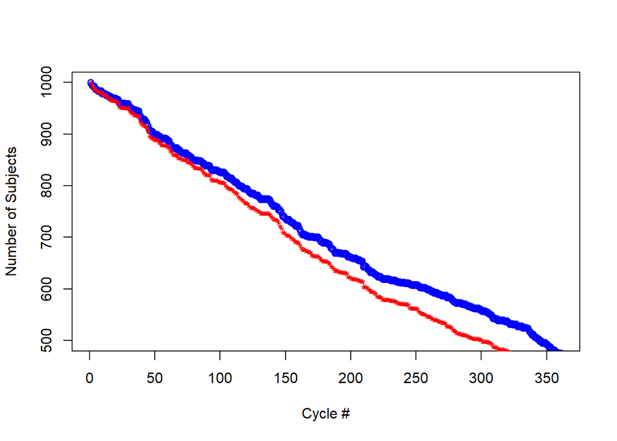

```
## integer(0)
```

Plot representing the subjects lost due to CVD deaths with each cycle transition with “Blue” for Treatment chort, and Red for No Treatment cohort

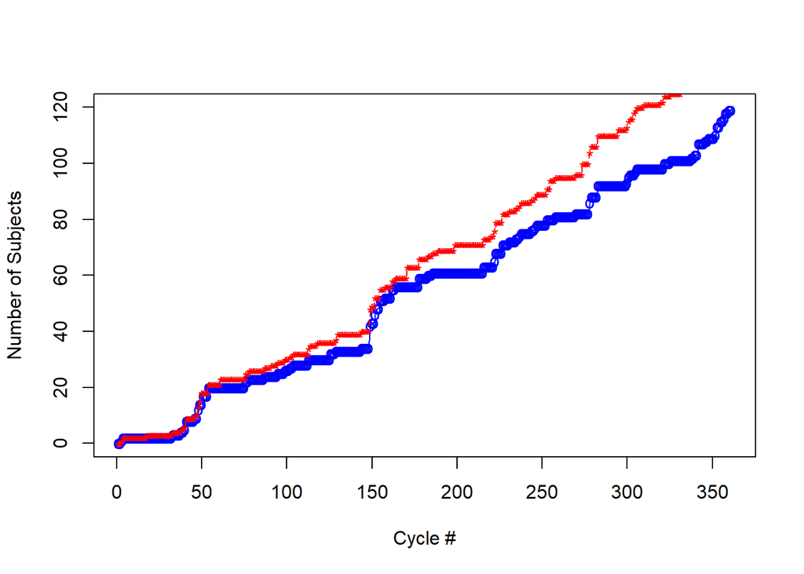

```
## integer(0)
```

```r
time_taken <- end_time - start_time
time_taken
```

```
## Time difference of 18.33552 secs
```

Limitations of the current model:  
1. The transition matrix probabilities need to be refined - We can have a detailed discussion on this  
2. The cohort should ideally be run till end of age (ie. death or age=80+ years), but I need to modify the p.W_CVD into a dynamic formula which calculates value based on the risk factor parameters for the individual  
3. The model assumes subjects to eternally stay in MI or Stroke state, and doesn’t consider movement back to Well state.